# Brownian motion on an upswitch

Peter Ralph and Josh Shiffman

2017-06-13

# Model

Consider the dynamical system given by
$$\begin{aligned}
\dot{x}(t) &= Ax(t) + Bu(t) \\
y(t) &= Cx(t)
\end{aligned}$$
where
$$\begin{aligned}
B^{T} = \begin{bmatrix} 1 & 0 \end{bmatrix}, \qquad C = \begin{bmatrix} 0 & 1 \end{bmatrix}
\end{aligned}$$
and
$$\begin{aligned}
A = \begin{bmatrix} -1 & 0 \\ 1 & 0 \end{bmatrix} .
\end{aligned}$$
This system has impulse response function
$$\begin{aligned}
h(t) &= C e^{tA} B \\
&= 1 - e^{-t} .
\end{aligned}$$
The set of equivalent $A$ are given by $\{A(\tau): \tau \neq 1 \in \R\}$, where
$$\begin{aligned}
V(\tau)
&= \begin{bmatrix} 1 & \tau \\ 0 & 1 \end{bmatrix} \\
A(\tau)
&= V(\tau) A V(\tau)^{-1}
\end{aligned}$$
These systems are input-output equivalent (although may have different noise properties).

```r
A0 <- matrix(c(-1,1,0,0), nrow=2)
B <- matrix(c(1,0), ncol=1)
C <- matrix(c(0,1), nrow=1)
V <- function (tau) { matrix(c(1,0,tau,1), nrow=2) }
Vinv <- function (tau) { matrix(c(1,0,-tau,1), nrow=2) }
A_fn <- function (tau) { V(tau) %*% A0 %*% Vinv(tau) }
h <- function (t,tau=0,A=A_fn(tau)) { sapply(t, function (tt) C %*% expm(tt*A) %*% B) }
optimal_h <- function (t) { 1 - exp(-t) }
```

Here is the impulse response function:

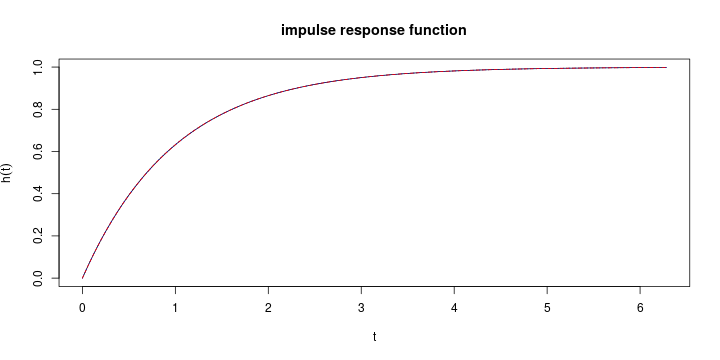

```r
tt <- seq(0,2*pi, length.out=100)
plot(tt, h(tt), type='l',
     xlab='t', ylab=expression(h(t)), main='impulse response function')
lines(tt, h(tt, tau=0.1), col='blue', lty=3)
lines(tt, optimal_h(tt), col='red', lty=2)
```

```r
if (do.pdfs) { pdf_copy() }
```

```
## pdf version at: figure/upswitch/impulse_response_plot-1.pdf
```

We can define the dynamics in two ways: extrinsically or intrinsically. Extrinsically, we look at the dynamics of a population mean in $\R^{2\times 2}$, thinking about $A$ as evolving. Intrinsically, we move about only on the set of equivalent $A$, letting $\tau$ evolve. As the population size goes to infinity, the extrinsic dynamics should approach the intrinsic dynamics.

# Extrinsic dynamics

Let $N$ denote the population size, and suppose that at any time the population is spread about from the mean $A$ as a Gaussian with variance $\sigma^2$, independently in each entry of $A$. Then we expect that the population mean takes steps of size $\sigma/\sqrt{N}$ with a restoring force towards the set of optimal $A$.

# Fitness of hybrids

```r
Df <- function (A,t) {
    exp(-t/(4*pi)) * ( h(t,A=A) - optimal_h(t) )^2
}
D <- function (A, upper=10, ...) {
    f <- function (t) { Df(A,t) }
    integrate(f, lower=0, upper=upper, ...)$value
}
```

To check this works, the distance of $A(2)$ to optimal should be zero:

```r
D(A_fn(2))
```

```
## [1] 2.005926e-29
```

We also need to be able to produce F1s and F2s:

```r
F1 <- function (tau1,tau2) { (A_fn(tau1)+A_fn(tau2))/2 }

gamete <- function (X,Y,rows) {
    out <- X
    out[rows,] <- Y[rows,]
    return(out)
}

F2 <- function (tau1, tau2, rows1, rows2) {
    (gamete(A_fn(tau1), A_fn(tau2), rows1) + gamete(A_fn(tau1), A_fn(tau2), rows2))/2
}

random_F2 <- function (tau1, tau2) {
    rows1 <- (rbinom(2,size=1,prob=1/2)>0)
    rows2 <- (rbinom(2,size=1,prob=1/2)>0)

    F2(tau1, tau2, rows1, rows2)
}

all_F2s <- function (tau1, tau2) {
    all_rows <- as.matrix(do.call( expand.grid, list(c(TRUE,FALSE))[rep(1,4)] ))
    lapply(1:nrow(all_rows), function (k) {
                x <- all_rows[k,]
                F2(tau1, tau2, x[1:2], x[3:4])
            })
}
```

Here are the phenotypes for $\tau=2$, $\tau=2.01$, and the hybrids:

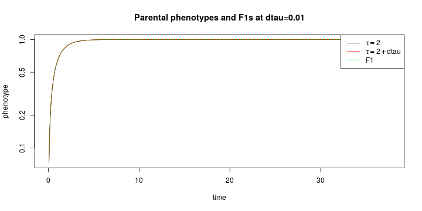

```r
dtau <- .01
tt <- seq(0,6*2*pi, length.out=500)
hh <- sapply( list(A_fn(2), A_fn(2+dtau), F1(2, 2+dtau)), function (A) { sapply(tt, h, A=A) } )
matplot(tt, hh, type='l', main=sprintf("Parental phenotypes and F1s at dtau=%s", dtau), lty=c(1,1,2), col=1:3, xlab="time", ylab="phenotype", log='y')
legend("topright", lty=c(1,1,2), col=1:3,
        legend=c(expression(tau==2), expression(tau==2+dtau), "F1"))
```

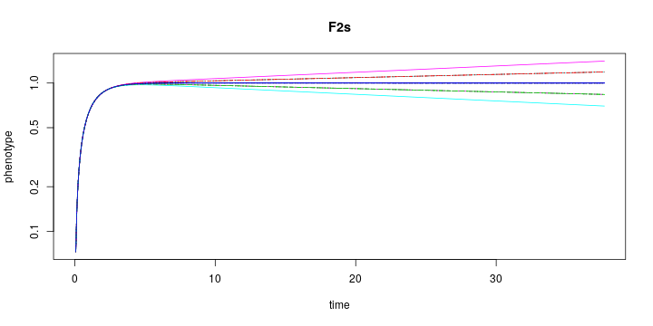

```r
# now the F2s
hh <- sapply( all_F2s(2, 2+dtau), function (A) { sapply(tt, h, A=A) } )
matplot(tt, hh, type='l', main="F2s", xlab="time", ylab="phenotype", log='y')
```

```r
if (do.pdfs) { pdf_copy() }
```

```
## pdf version at: figure/upswitch/phenotypes-1.pdf
```

And, the same thing for $\tau=2.1$:

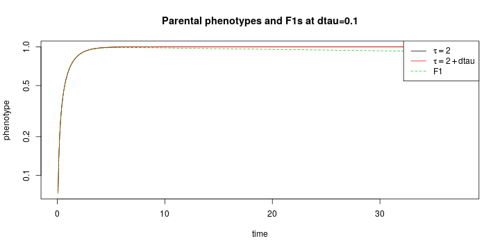

```r
dtau <- .1
tt <- seq(0,6*2*pi, length.out=500)
hh <- sapply( list(A_fn(2), A_fn(2+dtau), F1(2, 2+dtau)), function (A) { sapply(tt, h, A=A) } )
matplot(tt, hh, type='l', main=sprintf("Parental phenotypes and F1s at dtau=%s", dtau), lty=c(1,1,2), col=1:3, xlab="time", ylab="phenotype", log='y')
legend("topright", lty=c(1,1,2), col=1:3,
        legend=c(expression(tau==2), expression(tau==2+dtau), "F1"))
```

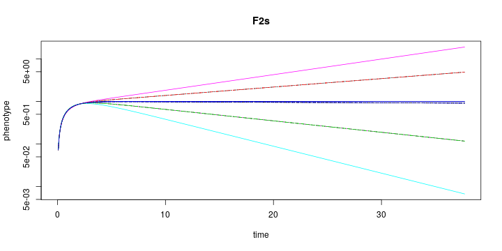

```r
# now the F2s
hh <- sapply( all_F2s(2, 2+dtau), function (A) { sapply(tt, h, A=A) } )
matplot(tt, hh, type='l', main="F2s", xlab="time", ylab="phenotype", log='y')
```

```r
if (do.pdfs) { pdf_copy() }
```

```
## pdf version at: figure/upswitch/phenotypes2-1.pdf
```

These F2s have distances of $D=$:

```r
sort(round(sapply(all_F2s(2, 2+dtau), function (x) D(A=x, upper=100, subdivisions=500)),2))
```

```
##  [1]     0.00     0.00     0.02     0.02     0.02     0.02     2.62
##  [8]     2.62     2.62     2.62     4.90   108.41   108.41   108.41
## [15]   108.41 52260.73
```

Now let's look at $D$ as a function of $d\tau$:

```r
dvec <- seq(0, .02, length.out=20)
D_F1 <- sapply(dvec, function (dtau) {
            D(A=F1(tau1=2, tau2=2+dtau))
        } )

D_F2 <- do.call(cbind, mclapply(dvec, function (dtau) {
            F2s <- all_F2s(2, 2+dtau)
            sapply(F2s, D, upper=100)
        }, mc.cores=detectCores() ) )
```

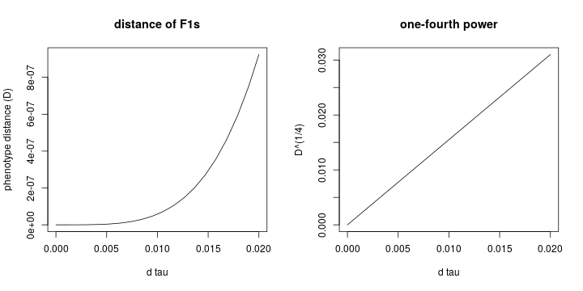

```r
layout(t(1:2))
plot( dvec, D_F1, type='l', xlab="d tau", ylab="phenotype distance (D)", main="distance of F1s")
plot( dvec, D_F1^(1/4), type='l', main="one-fourth power", xlab="d tau", ylab="D^(1/4)")
```

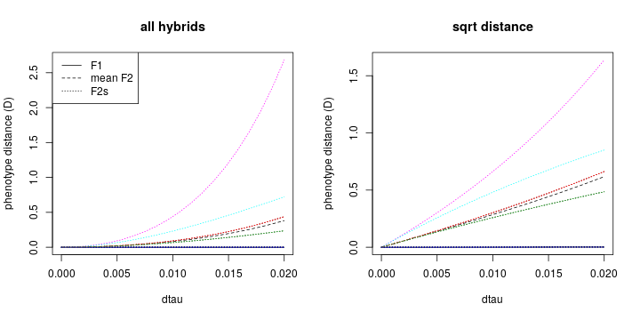

```r
plot( dvec, D_F1, type='l', ylim=range(D_F2, D_F1),
        xlab="dtau", ylab='phenotype distance (D)',
        main="all hybrids")
lines(dvec, colMeans(D_F2), lty=2)
matlines(dvec, t(D_F2), lty=3)
legend("topleft", lty=c(1,2,3), legend=c("F1", "mean F2", "F2s"))

plot( dvec, sqrt(D_F1), type='l', ylim=sqrt(range(D_F2, D_F1)),
        xlab="dtau", ylab='phenotype distance (D)',
        main="sqrt distance")
lines(dvec, sqrt(colMeans(D_F2)), lty=2)
matlines(dvec, sqrt(t(D_F2)), lty=3)
```

```r
if (do.pdfs) { pdf_copy() }
```

```
## pdf version at: figure/upswitch/plot_d_fn-1.pdf
```